```python
import numpy as np
import matplotlib.pyplot as plt
import sys
```

# Домашня робота № 4 «Розв’язування задач лінійного програмування.»

## Варіант 1

### Завдання 1. Розв’язати задачі:

- задачу 1 графічним методом (разом з лекцією прикріплене відео з поясненнями);
- задачу 2 симплекс-методом за допомогою онлайн-калькулятора на сайті https://www.pmcalculators.com/simplex-method-calculator/

#### Задача 1.

Знайти оптимальні значення змінних $x_1$* та $x_2$*, такі, що приводять цільову функцію до екстремуму при заданих обмеженнях. Обчислити значення цільової функції $F(x_1*, x_2*)$. Задачу розв’язати графічним методом.

$ F = 4x_1 + 6x_2 \rightarrow max \\ $  
$ \begin{cases} 2x_1 + 4x_2 <= 16 \\ x_1 + x_2 <= 6 \\ x_1 + 4x_2 <= 14 \end{cases} \\ $  
$ x_1 >= 0,\ x_2 >= 0 $

Відповідь:

1. оптимальні значення параметрів $х_1$* = 4; $х_2$* = 2;
2. найбільше значення цільової функції $F(х_1*, х_2*)$ = 28.0.

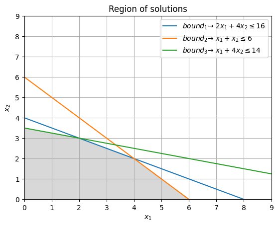

```python
# Define the inequalities
x = np.linspace(0, 10, 400)
bound_1 = (16 - 2*x) / 4
bound_2 = 6 - x
bound_3 = (14 - x) / 4
F = 4 * x / 6

plt.plot(x, bound_1, label=r'$bound_1 →\ 2x_1 + 4x_2 \leq 16$')
plt.plot(x, bound_2, label=r'$bound_2 →\ x_1 + x_2 \leq 6$')
plt.plot(x, bound_3, label=r'$bound_3 →\ x_1 + 4x_2 \leq 14$')

plt.fill_between(x, np.minimum(np.minimum(bound_1, bound_2), bound_3), 0, where=(x >= 0) & (bound_1 >= 0) & (bound_2 >= 0) & (bound_3 >= 0), color='grey', alpha=0.3)

plt.xlabel(r'$x_1$')
plt.ylabel(r'$x_2$')
plt.title('Region of solutions')
plt.legend()

plt.grid(True)
plt.xlim(0, 9)
plt.ylim(0, 9)
plt.show()
```

#### Точки перетину:

$ \begin{cases} x_1 + 4x_2 = 14 \\ x_1 = 0 \end{cases} \\ $  
$x_2 = 3.5$  
$A = (0, 3.5)$

$ \begin{cases} 2x_1 + 4x_2 <= 16 \\ x_1 + 4x_2 <= 14 \end{cases} \\ $  
$2x_1 - x_1 + 4x_2 - 4x_2 = 16 - 14$  
$x_1 = 2$  
$4x_2 = 14 - 2$  
$x_2 = 3$  
$B = (2, 3)$

$ \begin{cases} 2x_1 + 4x_2 <= 16 \\ x_1 + x_2 <= 6 \end{cases} \\ $  
$2x_1 - 2x_1 + 4x_2 - 2x_2 = 16 - 6 * 2$  
$2x_2 = 4$  
$x_2 = 2$  
$x_1 = 4$  
$C = (4, 2)$

$ \begin{cases} x_1 + x_2 <= 6 \\ x_2 = 0 \end{cases} \\ $  
$x_1 = 6$  
$D = (6, 0)$

```python
corner_points = np.array([[0, 3.5], [2, 3], [4, 2], [6, 0]])

def F(x1, x2):
    return 4*x1 + 6*x2

max_value = float('-inf')
max_point = None

for point in corner_points:
    value = F(point[0], point[1])
    if value > max_value:
        max_value = value
        max_point = point

print(f"Max value: {max_value} in point {[coord for coord in max_point]}")
```

```
Max value: 28.0 in point [4.0, 2.0]
```

#### Задача 2.

ЗАТ «МЕРЕЖА» випускає два види чутливих елементів: датчики руху та датчики освітленості.  
Для виготовлення одного датчика руху потрібно витратити:

- 2 м проводу
- 3 світлодіоди
- 1 регулятор

Для виготовлення одного датчика освітленості:

- 1 м проводу
- 4 світлодіода
- 3 регулятора

Виробництво забезпечено сировиною кожного типу у кількості:

- 400 м проводу
- 900 світлодіодiв
- 600 регуляторiв

Вартість:

- датчика руху = 120 грн
- датчика освітленості = 80 грн.

Складіть план виробництва чутливих елементів, який забезпечить максимальний прибуток від реалізації. Скласти математичну модель рішення задачі (цільову функцію та обмеження) та розв’язати симплекс-методом.

Відповідь:  
$ F = 120x_1 + 80x_2 \rightarrow max \\ \begin{cases} 2x_1 + x_2 <= 400 \\ 3x_1 + 4x_2 <= 900 \\ x_1 + 3x_2 <= 600 \\ x_1 >= 0 \\ x_2 >= 0 \end{cases} $

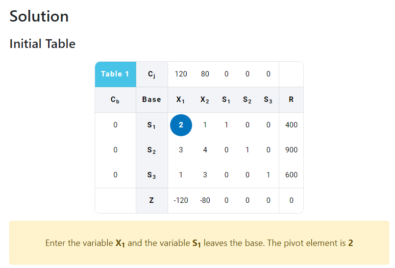

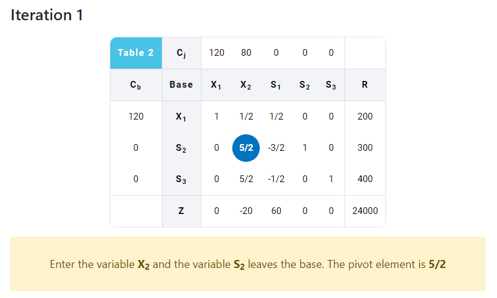

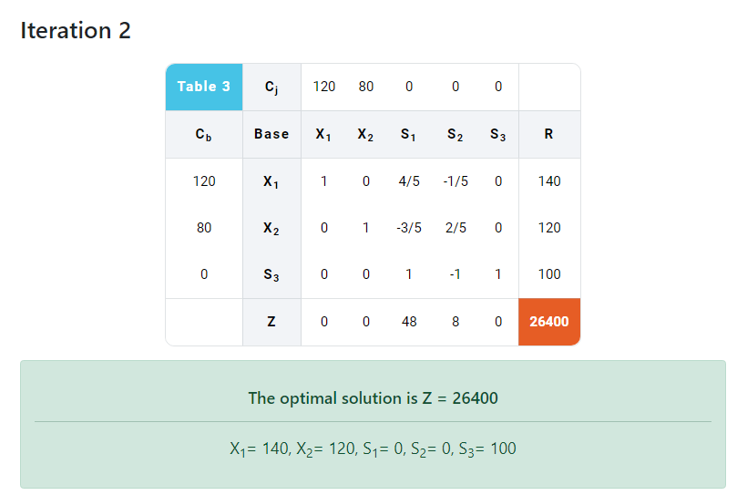

1. оптимальні значення параметрів $х_1*$ = 140; $х_2*$ = 120;
2. найбільше/найменше значення цільової функції $F(х_1*, х_2*)$ = 26400.